# Projeto2

#### Modelos de regressão múltipla - usando todas variáveis

##### Preco ~ area + garagem + quartos

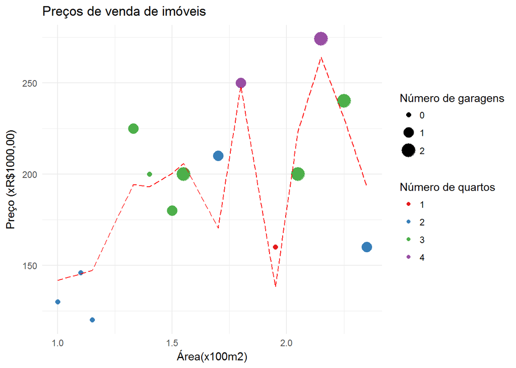

```
##
## Call:
## lm(formula = preco ~ area + garagem + quartos, data = housingSmall)
##
## Residuals:
##     Min      1Q  Median      3Q     Max
## -33.114 -18.172   1.328   9.879  39.794
##
## Coefficients:
##             Estimate Std. Error t value Pr(>|t|)
## (Intercept)   32.334     42.772   0.756  0.46711
## area          35.244     21.367   1.649  0.13007
## garagem        3.701     14.215   0.260  0.79986
## quartos       37.128     10.991   3.378  0.00703 **
## ---
## Signif. codes:  0 '***' 0.001 '**' 0.01 '*' 0.05 '.' 0.1 ' ' 1
##
## Residual standard error: 24.92 on 10 degrees of freedom
## Multiple R-squared:  0.7728, Adjusted R-squared:  0.7047
## F-statistic: 11.34 on 3 and 10 DF,  p-value: 0.001475
```

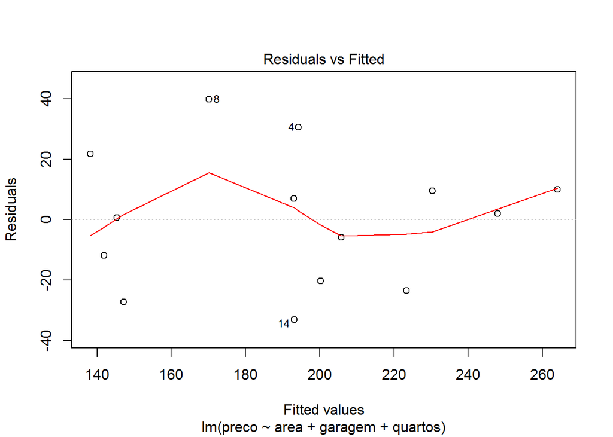

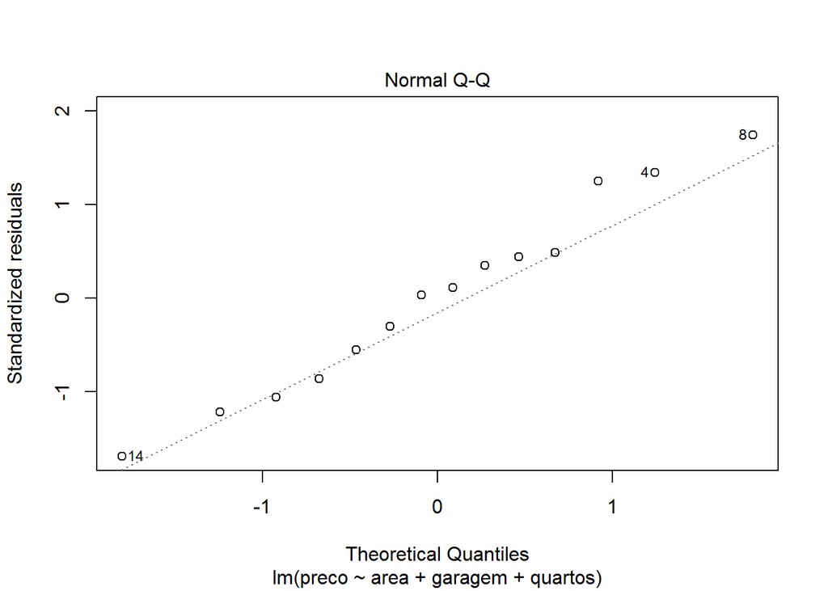

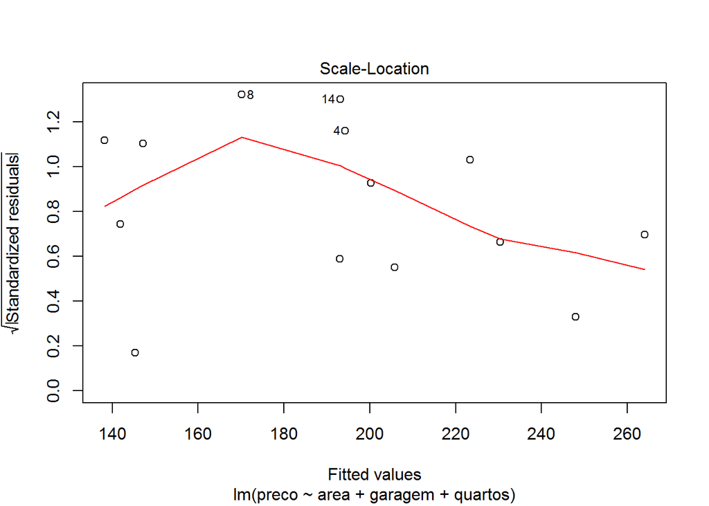

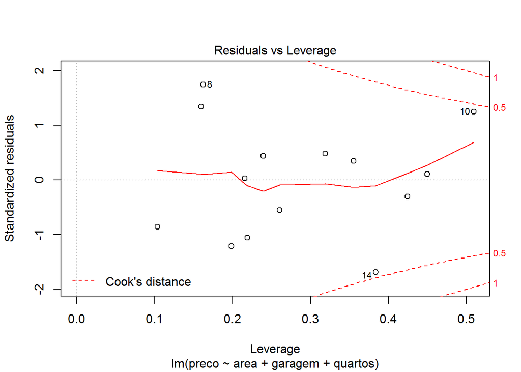

##### Preco ~ area * garagem * quartos

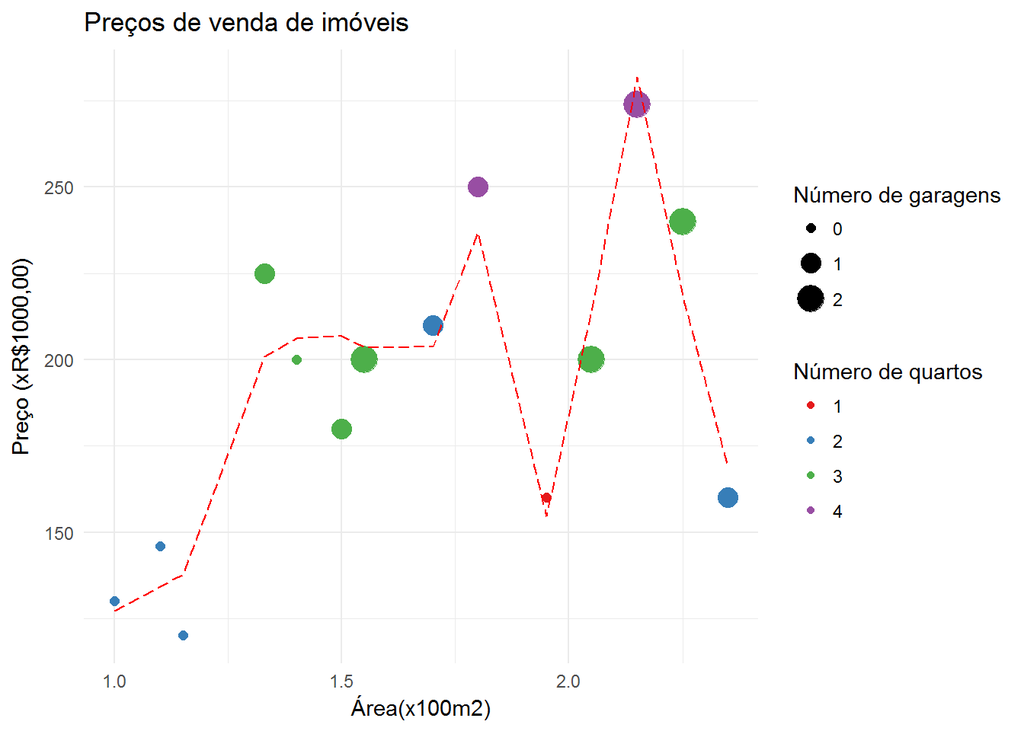

[output not shown]

[figure not shown]

[figure not shown]

[figure not shown]

[figure not shown]

Os modelos utilizando todas as variáveis tiveram valores altos de R<sup>2</sup> mas a análise de resíduos leva a conclusão de que também não são bons modelos.

### Conclusão

Nenhum dos modelos propostos conseguiu ter um valor razoavelmente alto de R<sup>2</sup> juntamente com um comportamento aceitável dos resíduos. Muitos dos modelos apresentaram problema de sobreajuste.

A maior limitação no desenvolvimento dos modelos foi a pequena quantidade de dados. Tendo mais informações, o modelo seria mais confiável.